# WallkillQAQC

Alene Onion

December 29, 2018

## QAQC overview

The components of our quality review are:

- Accuracy
  - A matrix spike is used to document the bias of a method in a given sample matrix.
  - designated ‘spike’ samples are spiked with a known concentration. The difference between the concentration before and after should be the spiked amount +/- the accuracy criteria established by the standard methods manual and listed in tables 3 and 4.
  - NOTE: the QAPP only requires that we analyze spikes for nutrients, metals and minerals (see section II.5.A.b)! Iâ€™m presuming this excludes solids, turbidity, conductivity, and hardness in addition to in situ parameters, alkalinity, DOC, and chlorophyll a
  - NOTE: we only examine the matrix spike samples. The matrix spike duplicate samples would only be analyzed when we are meausring organics. That’s not the case in any BWAM programs.
- Precision
  - Duplicate samples are analyzed from the same date/location to assess the method’s precision.
  - Previously, the % difference between these samples must satisfy the precision criteria set forth in table 3 (screening) and table 4 (routine). In this document, we propose using a new method developed by Ohio EPA that offers a curved threshold.
- Equipment Blank exceedances (result > reporting limit)
  - Step 1: identify a reporting limit based on the data collected in 2017+18
  - Step 2: pull EB values that exceed these reporting limits
  - Step 3: flag sample values that are less than 10x (flagged calculated), 5x (flagged trend), and 3x (rejected)
- Completeness: Did we collect all the samples we intended to
- Holding time exceedances
- Temperature upon receipt exceedances

## Associating Samples

Plotting the wallkill sample dates to understand how best to associate them.

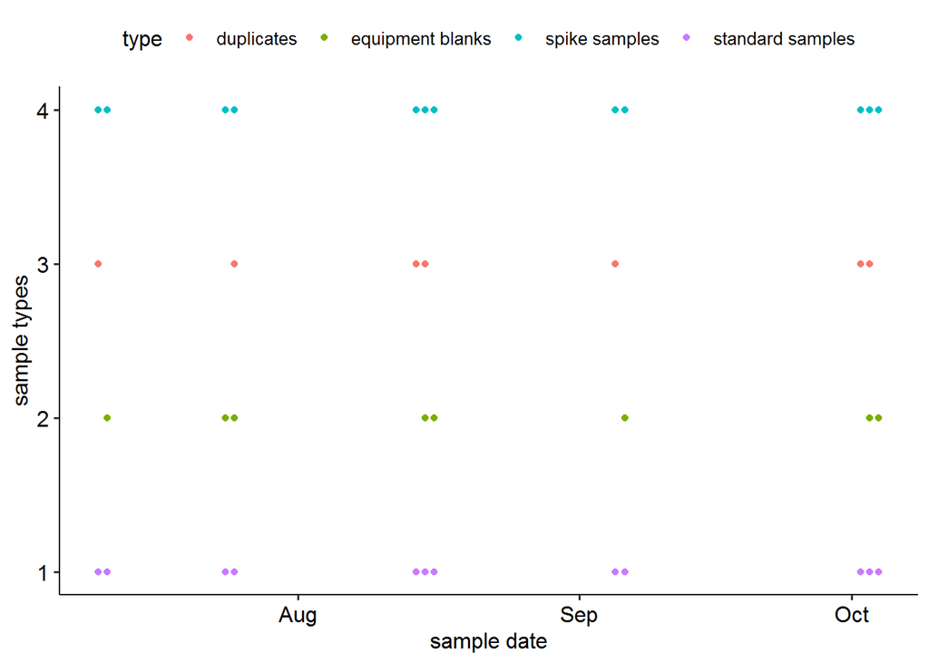

## Info from EDD reports

Conclusions drawn from reading lab reports  
I have to read these when I get back. Here are all the SDGs associated with these data:

[1] R1807890 R1806428 R1809618 R1808566 R1806960 R1808568 R1806961 [8] R1807868 R1809619 R1807891 R1807763 R1806544 R1807869 13 Levels: R1806428 R1806544 R1806960 R1806961 R1807763 … R1809619

## Accuracy Assessment

- Accuracy
  - A matrix spike is used to document the bias of a method in a given sample matrix.
  - designated ‘spike’ samples are spiked with a known concentration. The difference between the concentration before and after should be the spiked amount +/- the accuracy criteria established by the standard methods manual and listed in tables 3 and 4.
  - NOTE: the QAPP only requires that we analyze spikes for nutrients, metals and minerals (see section II.5.A.b)! Iâ€™m presuming this excludes solids, turbidity, conductivity, and hardness in addition to in situ parameters, alkalinity, DOC, and chlorophyll a
  - NOTE: we only examine the matrix spike samples. The matrix spike duplicate samples would only be analyzed when we are meausring organics. That’s not the case in any BWAM programs.

### Difficulties with this analysis

First of all, not all parameters had spike assessments (NA values means a spike analysis wasn’t performed on this parameter).  
I think this is ok because the QAPP only requires that we analyze spikes for nutrients, metals and minerals (see section II.5.A.b) and the nutrients that don’t have spike analyses are those that are calculated (for ex: nitrate is calculated from nitrate/nitrite - nitrite). Furthermore, those assessed by spike analysis, were not done so in at a regular, consistant, interval???

My sollution to associate each sample with the nearest (in time) spike analysis if any exist at all. I feel this is best because we aren’t assessing indivdual samplers, we’re assessing the impact the matrix has on the analysis. For other projects, we may want to segregate this analysis regionally. For the wallkill, I didn’t feel this was necessary.

Finally, it’s important to note that the spike fails I calculated, did not match the spike fails calculated by the lab. I need to investigate why to figure out if my calculation or the labs is incorrect. It is surprising that so many samples are flagged rejected by this.

### Rejected Samples

NOTE:this section of the script is slow because I had to use nested loops to associate each sample with the nearest spike analysis.

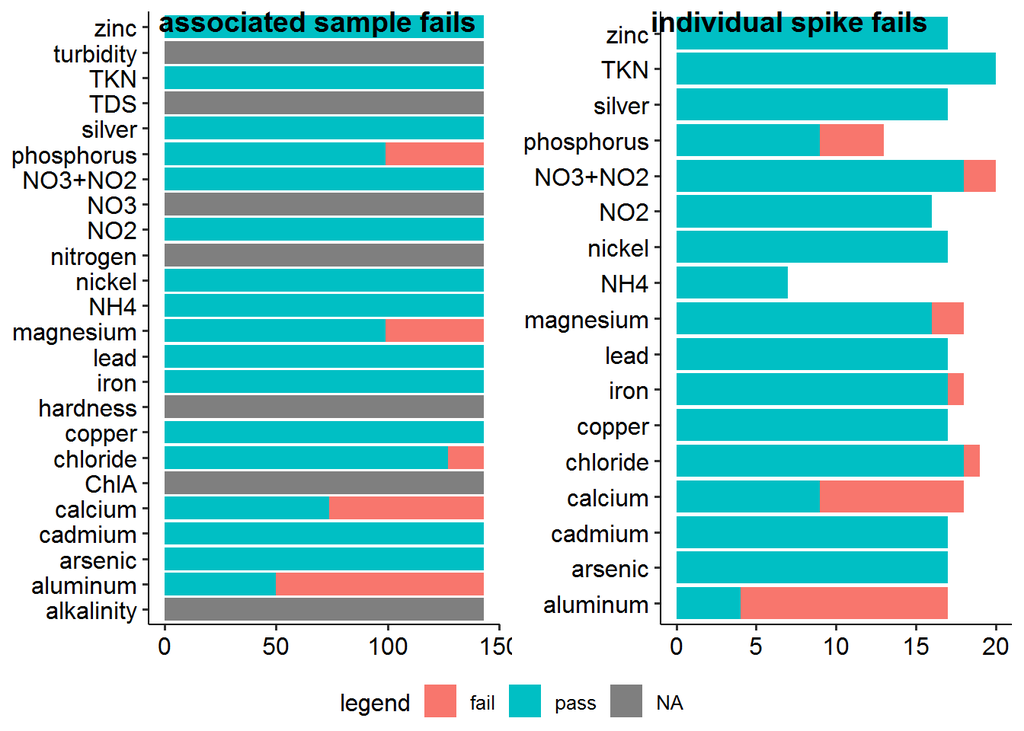

## Precision Assessment

- Precision
  - Duplicate samples are analyzed from the same date/location to assess the method’s precision.
  - Previously, the % difference between these samples must satisfy the precision criteria set forth in table 3 (screening) and table 4 (routine). In this document, we propose using a new method developed by Ohio EPA that offers a curved threshold.

The details of this method are given here: (https://www.epa.ohio.gov/portals/35/documents/sw_samplingmanual.pdf)

In short, they reject any duplicate sample pair where the %RPD > (0.9465x^-0.344)100 +5  
where: x = sample / detection limit %RPD = [diff(duplicate pair)/av(duplicate pair)]*100  
NOTE: they used the method detection limt but we might consider the quantitation limit  
NOTE: I used the maximum of the two samples to calculate x

### plots

To examin failures visually, I plotted sample/DL versus %RPD as well as the threshold equation described above.  
Any point above the line should be rejected. Any point below the line is accepted. If the line isn’t visible, that means it is above the range of the graph and all the points would be accepted.

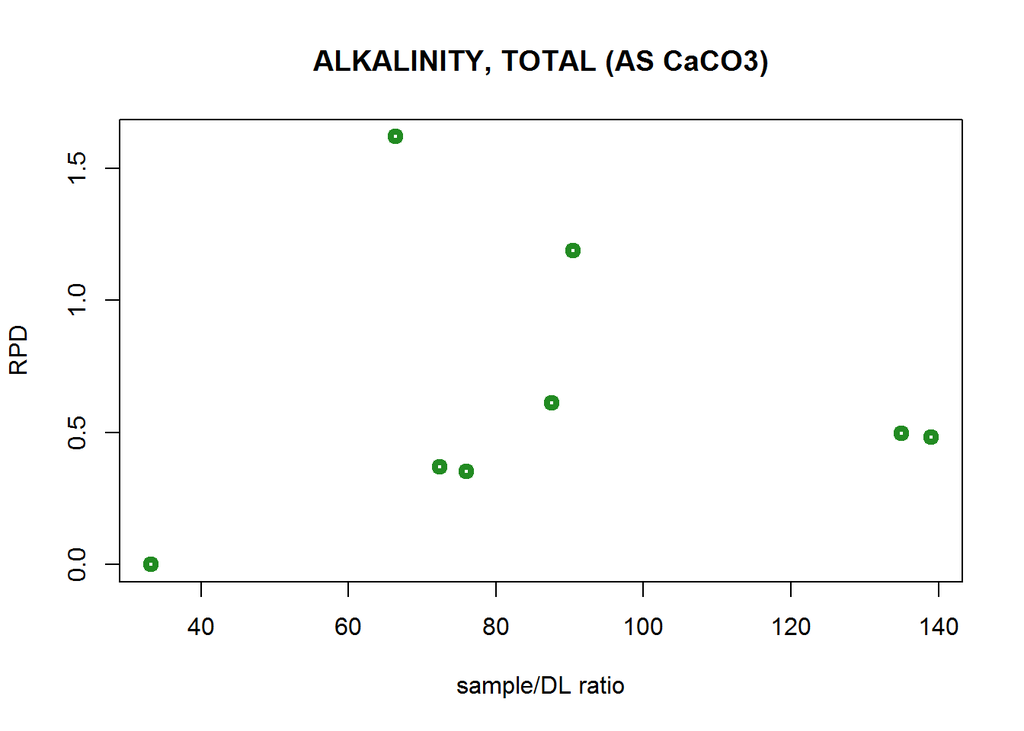

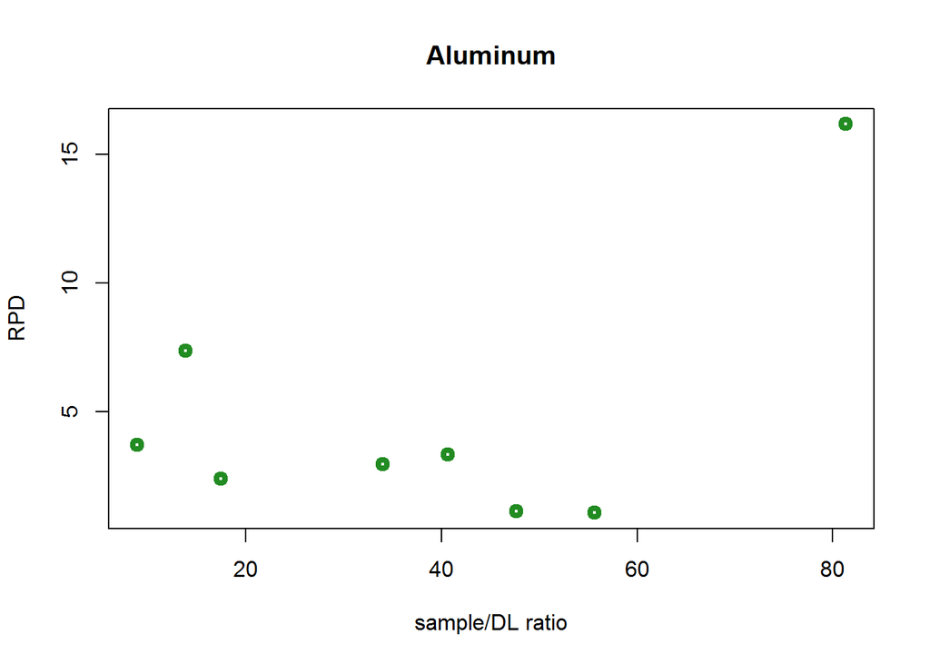

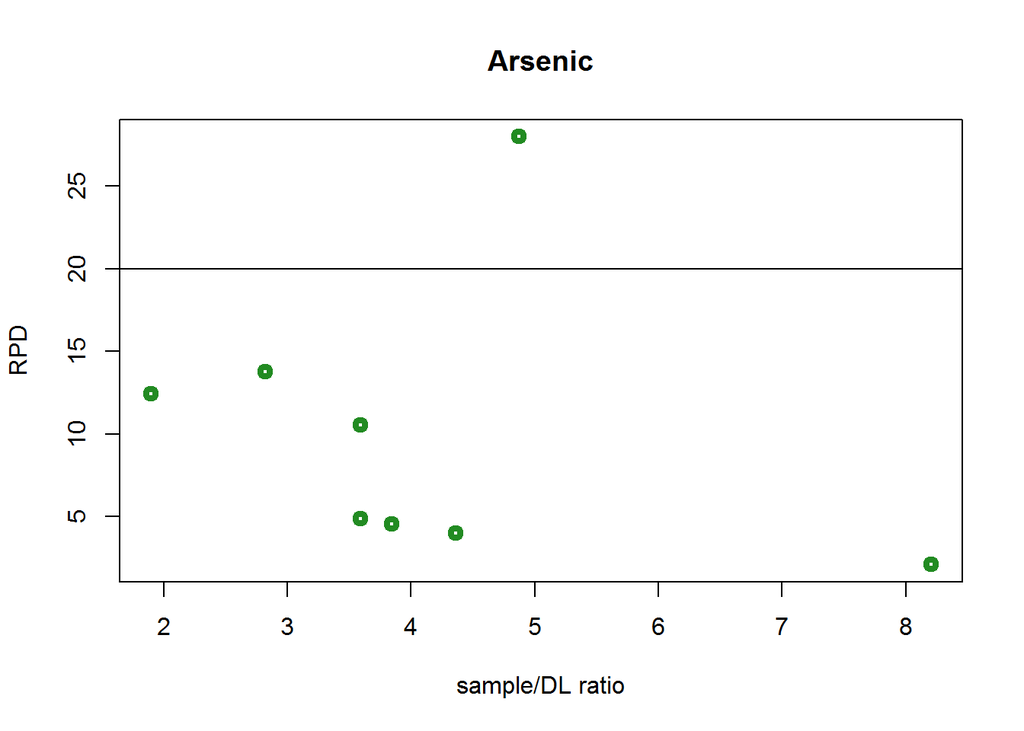

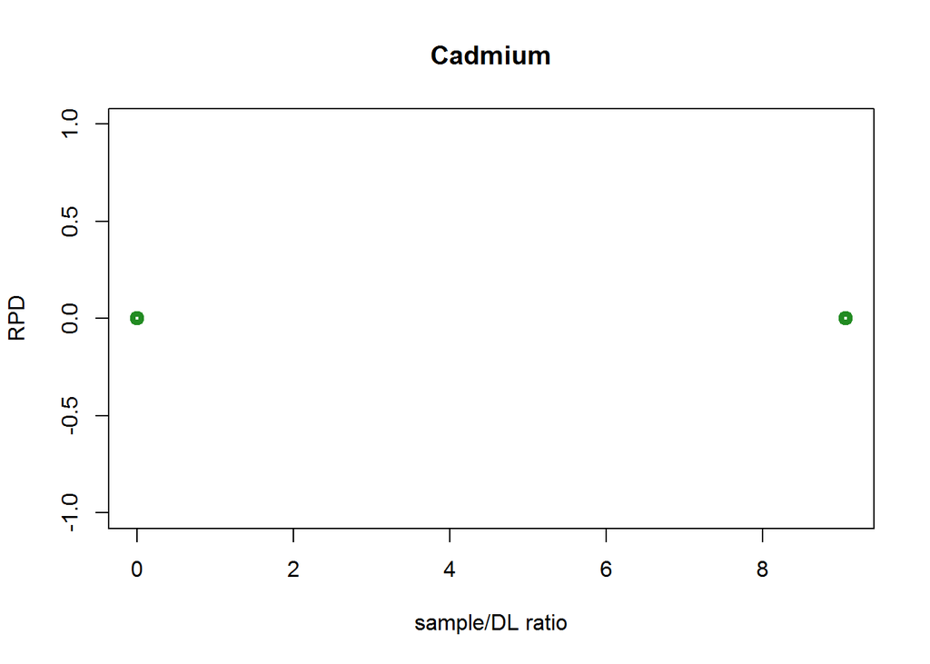

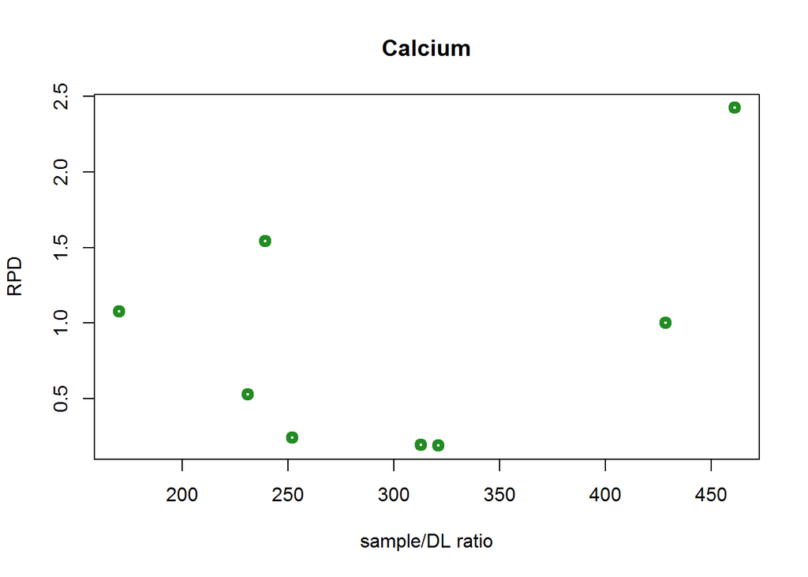

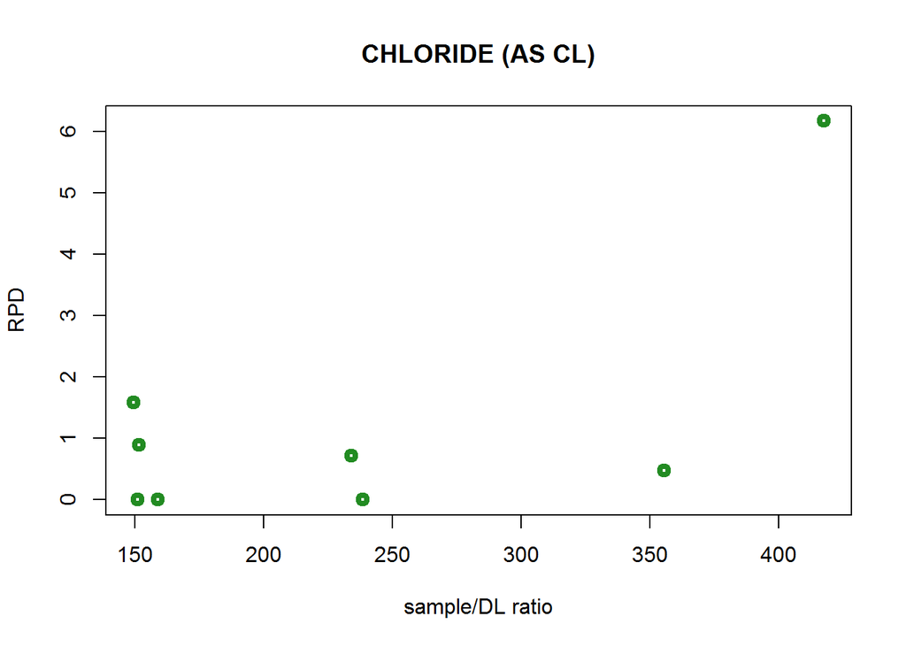

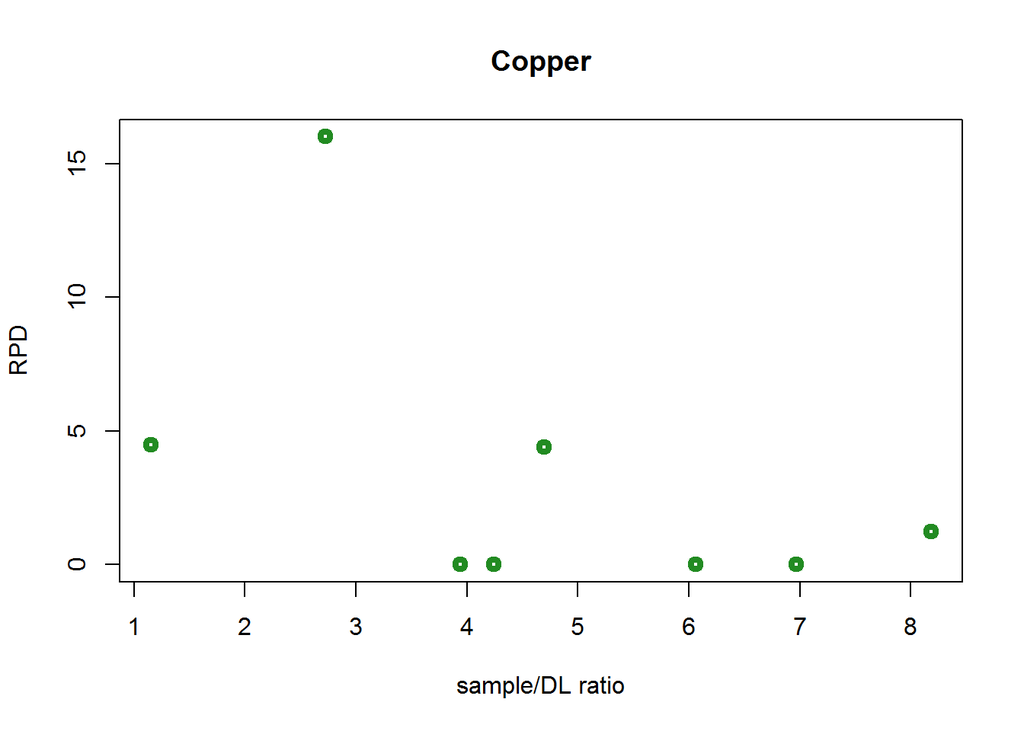

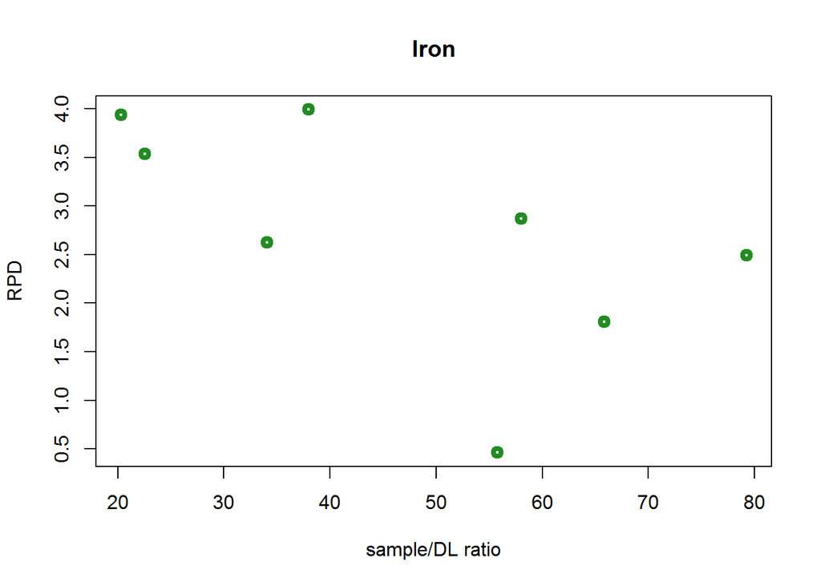

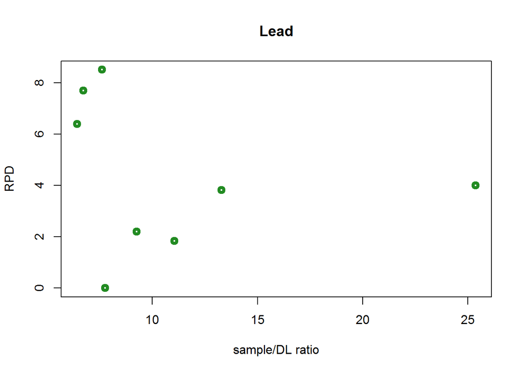

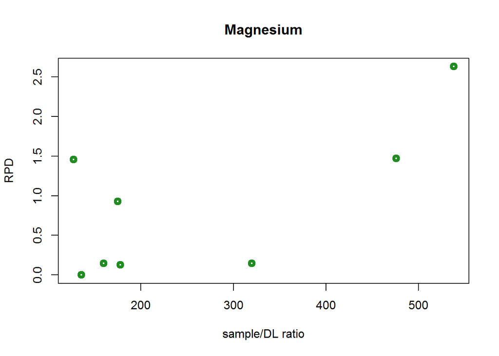

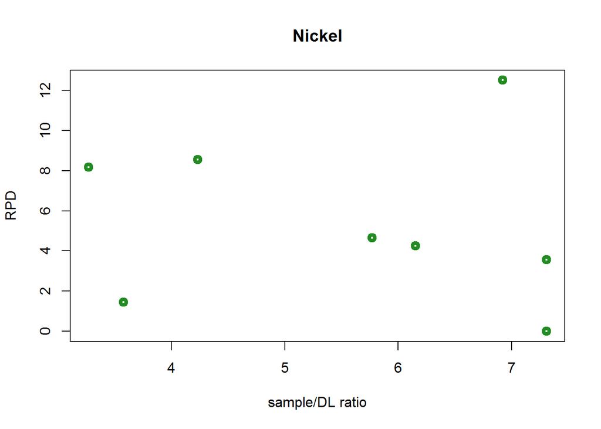

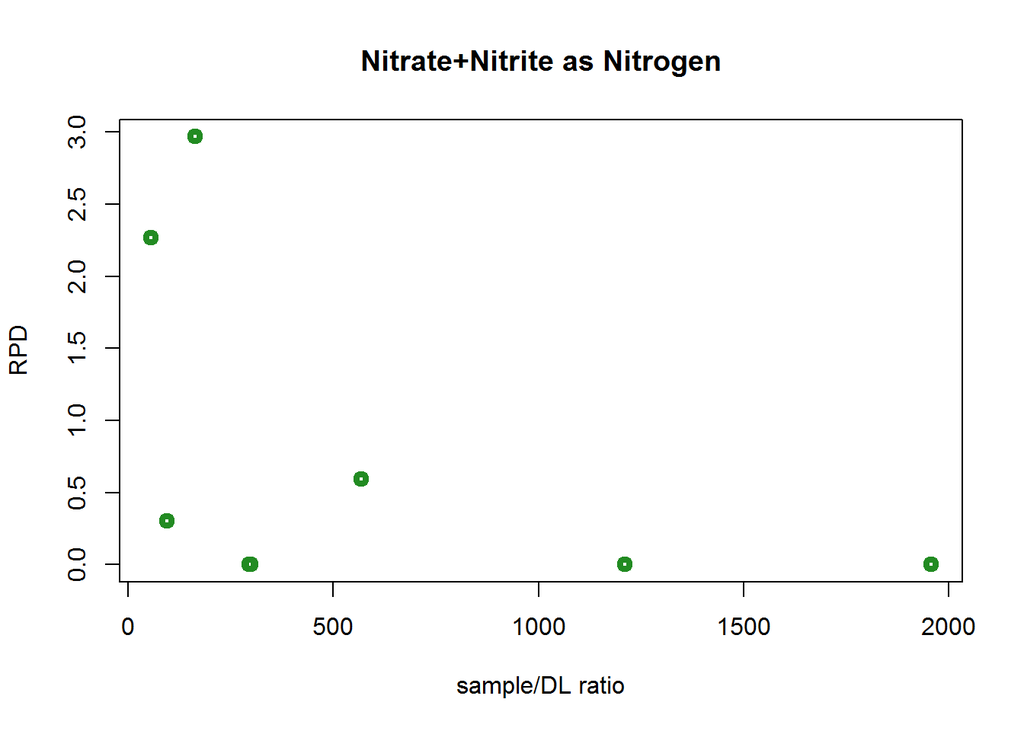

[8 more figures not shown]

### Rejected Samples

NOTE: I’m associate QC samples with those nearest in time. Originally, we were going to associate QC samples to all those samples collected by the same team but the field data available at this time are incomplete so I wasn’t able to do this. It still is a good option for future analyses.

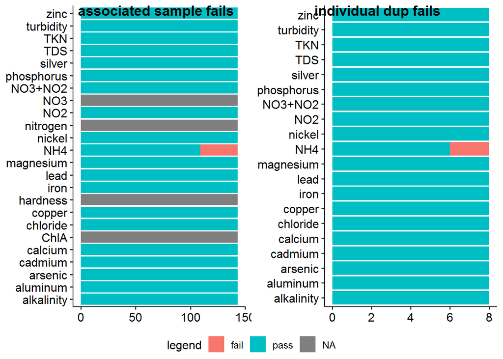

## Equipment Blanks

- Equipment Blank exceedances (result > reporting limit)
  - Step 1: identify a reporting limit based on the data collected in 2017+18
  - Step 2: pull EB values that exceed these reporting limits
  - Step 3: flag sample values associated with EB exceedences that are less than 10x (flagged calculated), 5x (flagged trend), and 3x (rejected) the equipment blank value

IT’S IMPORTANT TO NOTE: that the quantitation limit is NOT the reporting limit. It is set by the lab and can vary week to week (the method detection limit can as well). The reporting limit is the project goal (including field and lab errors) and the quantitation limit is what the lab alone achieved. It’s important to develop reporting limits specific to the needs of the project. For example, you may have a stricter reporting limit for a track down study than you would have for a screening survey.

These flags and their thresholds are again taken from OHIO EPA methods (https://www.epa.ohio.gov/portals/35/documents/sw_samplingmanual.pdf). Their detailed description is replicated below:

| Sample.Result | Interpretation |
| --- | --- |
| Sample <= 3x Blank | Reject sample results in this range as insufficiently different from blank results |
| 3x Blank < Sample <= 5x Blank | Likely indication that the analyte is present but poor confidence in the numerical result - generally limit data use to data “trend” applications |
| < 5x Blank < Sample <= 10x Blank | Consider the sample result to be an estimated concentration (qualified “J”) but still suitable for most data uses |
| < 10x Blank | Do not qualify data (blank contamination does not significantly change the result within the uncertainty of the value reported) |

### plots

I only plotted parameters with EB failures.  
The purpose of these plots is to see whether the failures were outliers or were part of an underlying noise. If the latter, then we should consider raising the reporting limit.  
NOTE: I turn non-detects into 0 which I know they are not but for the purpose of identifying failed EBs, I feel this is ok.

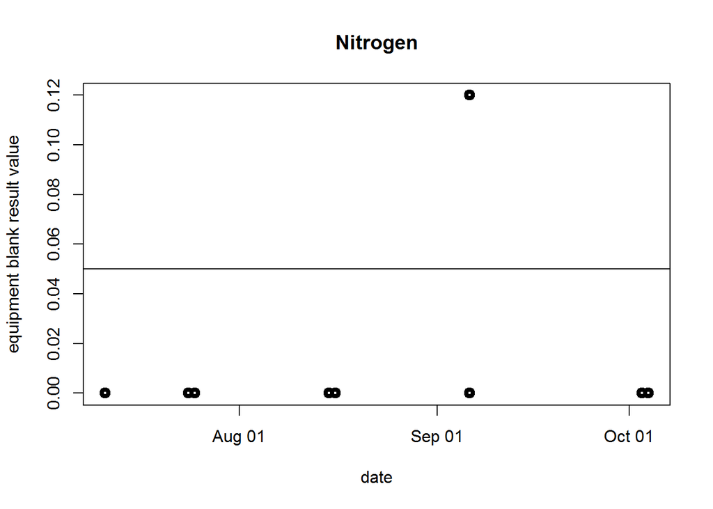

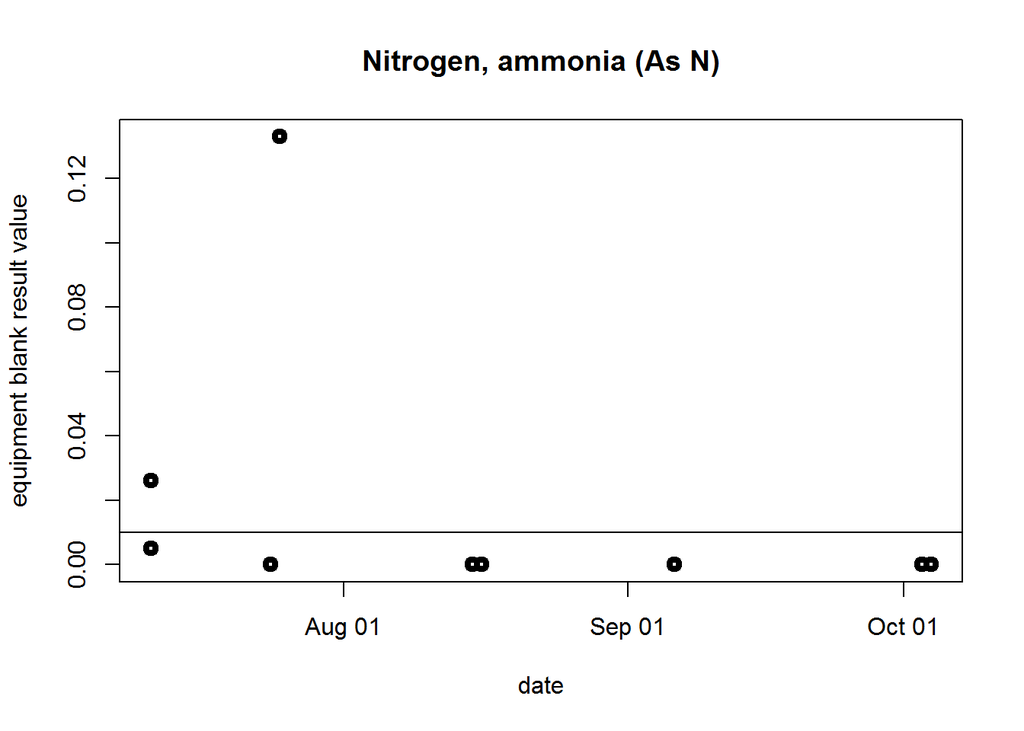

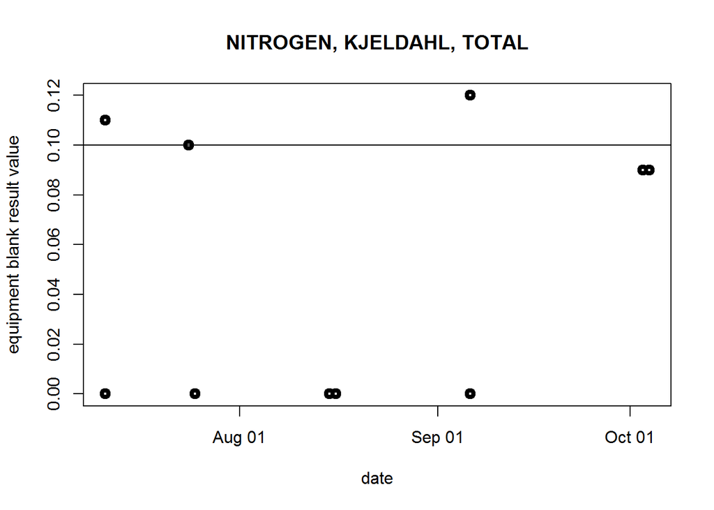

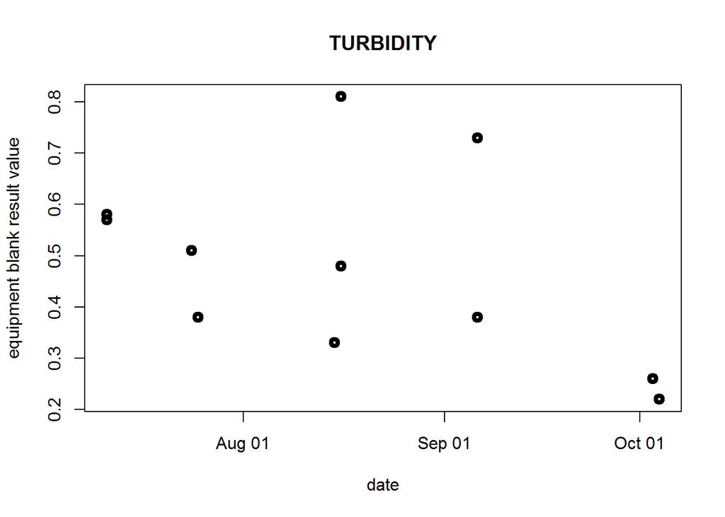

### Rejected Samples

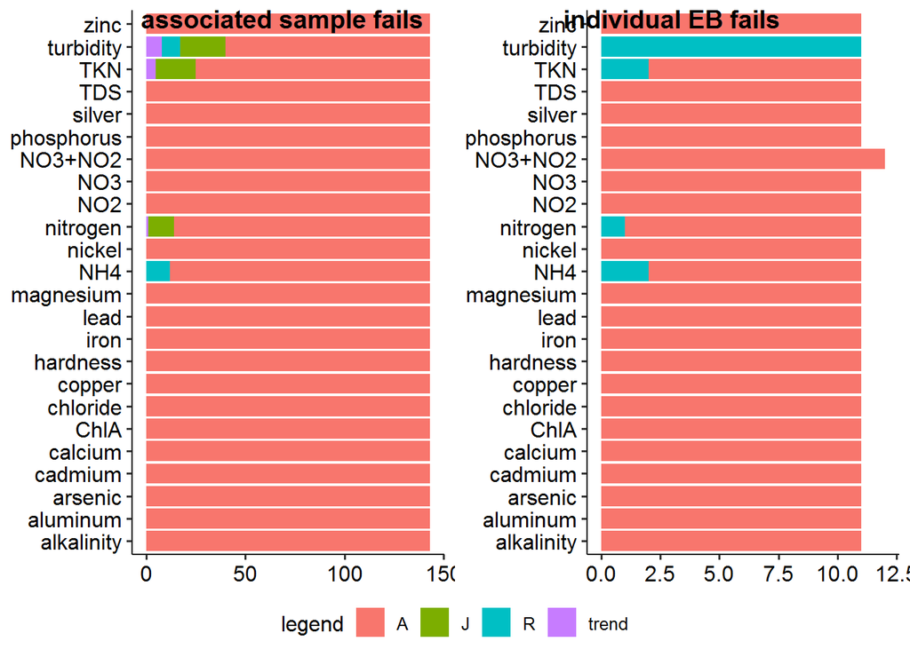